# Laboration 1

Andrew Dean & Ekaterina Kershinskaia

2026-11-18

# Sammanfattning

Den här laborationen handlar om att använder diagram för att visualisera datamängder.

# Uppgift 2

I denna uppgift vill vi undersöka förbrukning av olika plottar för att avgöra om en datamängd är normalfördelad eller inte.

### 2.1.

```r
plot_hist_qq <- function(d1, d2, d3) {
  old_par <- par(mfcol = c(2,3))  # 2 rader, 3 kolonner
  for (d in list(d1, d2, d3)) {
    hist(d, main = sprintf("Histogram, n=%d", length(d)),
         xlab = "Värde", ylab = "Frekvens")
    qqnorm(d, main = sprintf("Q-Q plot, n=%d", length(d)),
           xlab = "Teoretiska Kvantiler", ylab = "Stickprovskvantiler")
    qqline(d)
  }
  par(old_par) # säg åt R att sluta förvänta sig fler plottar till samma fönster
}

plot_box <- function(d1, d2, d3) {
  boxplot(d1, d2, d3,
          names = c(sprintf("n=%d", length(d1)), sprintf("n=%d", length(d2)), sprintf("n=%d", length(d3))),
          main = "Boxplottar av olika antal observationer",
          xlab = "Stickprovsstorlek", ylab = "Värde",
          col = c("#4fc3f7", "#81c784", "#ffb74d"))
}
```

```r
a <- 26
```

```r
set.seed(19690420)
n1 <- rnorm(20, a, a)
n2 <- rnorm(80, a, a)
n3 <- rnorm(320, a, a)
```

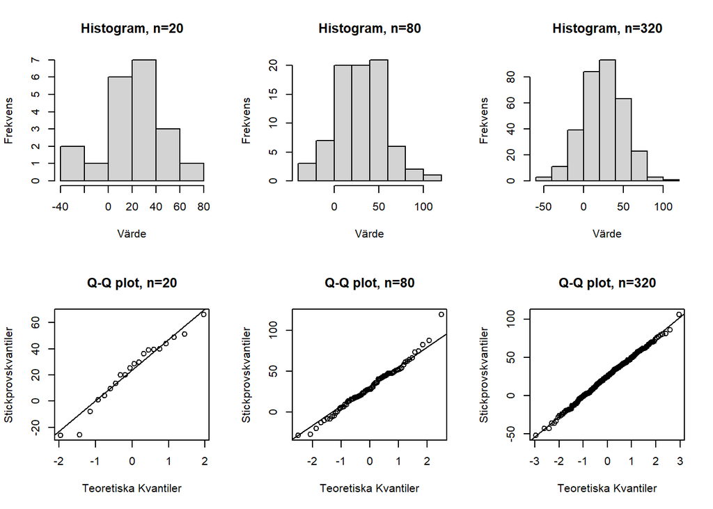

Histogram och Q-Q plottar från $N(26, 26^2)$ med n=20, n=80, respektiv n=320 observationer.

```r
plot_hist_qq(n1, n2, n3)
```

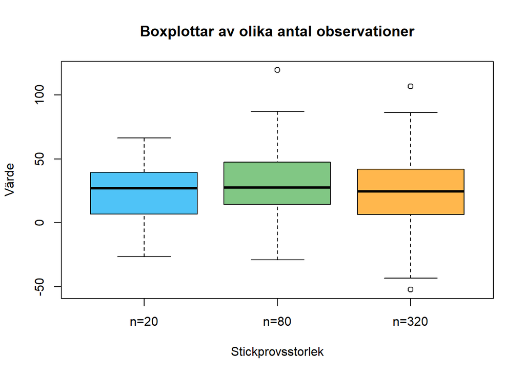

Boxplot av $N(26, 26^2)$ med n=20, n=80, respektiv n=320 observationer.

```r
plot_box(n1, n2, n3)
```

```r
set.seed(19980226)
t1 <- (a/sqrt(2))*rt(20, 4) + a
t2 <- (a/sqrt(2))*rt(80, 4) + a
t3 <- (a/sqrt(2))*rt(320, 4) + a
```

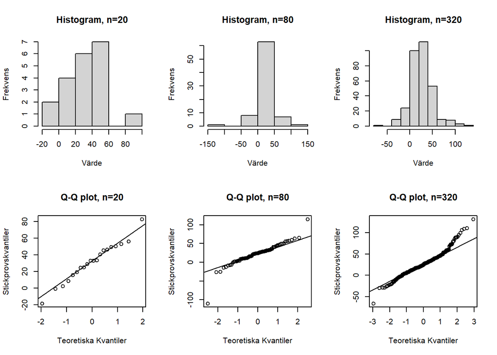

Histogram och Q-Q plottar från $\left(\frac{26}{\sqrt{2}}t_4 + 26\right)$ med n=20, n=80, respektiv n=320 observationer.

```r
plot_hist_qq(t1, t2, t3)
```

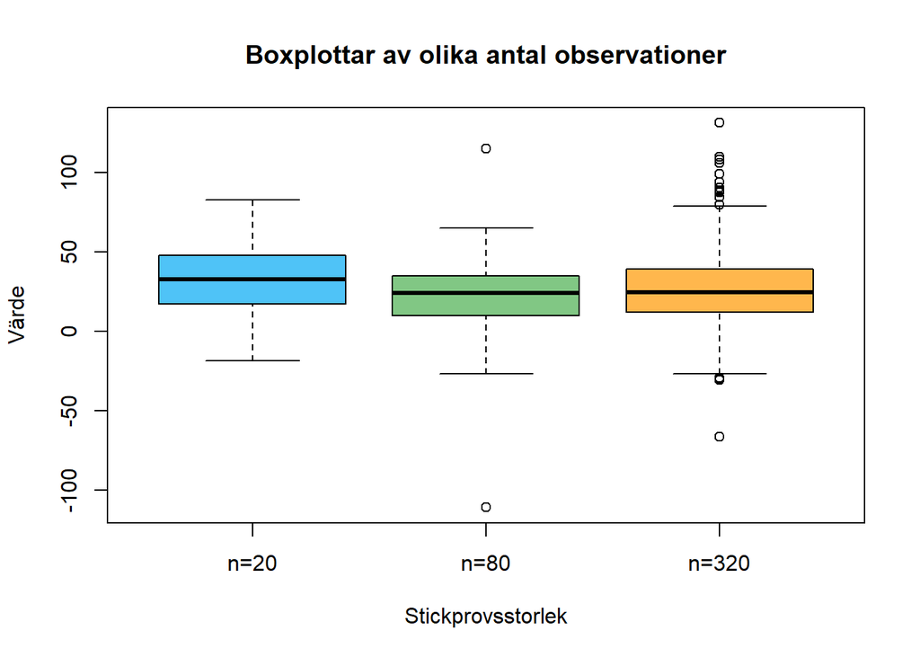

Boxplot av $\left(\frac{26}{\sqrt{2}}t_4 + 26\right)$ med n=20, n=80, respektiv n=320 observationer.

```r
plot_box(t1, t2, t3)
```

```r
set.seed(19981207)
lower <- (1 - sqrt(3))*a
upper <- (1 + sqrt(3))*a
u1 <- runif(20, lower, upper)
u2 <- runif(80, lower, upper)
u3 <- runif(320, lower, upper)
```

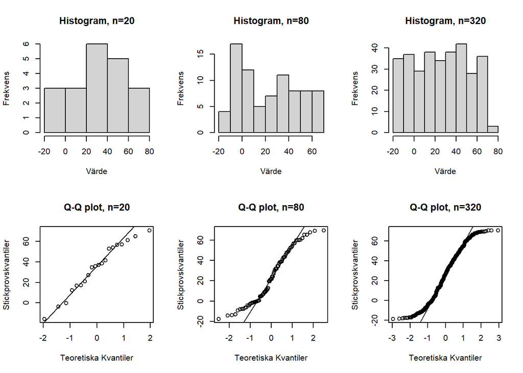

Histogram och Q-Q plottar från $U(-19.03, 71.03)$ med n=20, n=80, respektiv n=320 observationer.

```r
plot_hist_qq(u1, u2, u3)
```

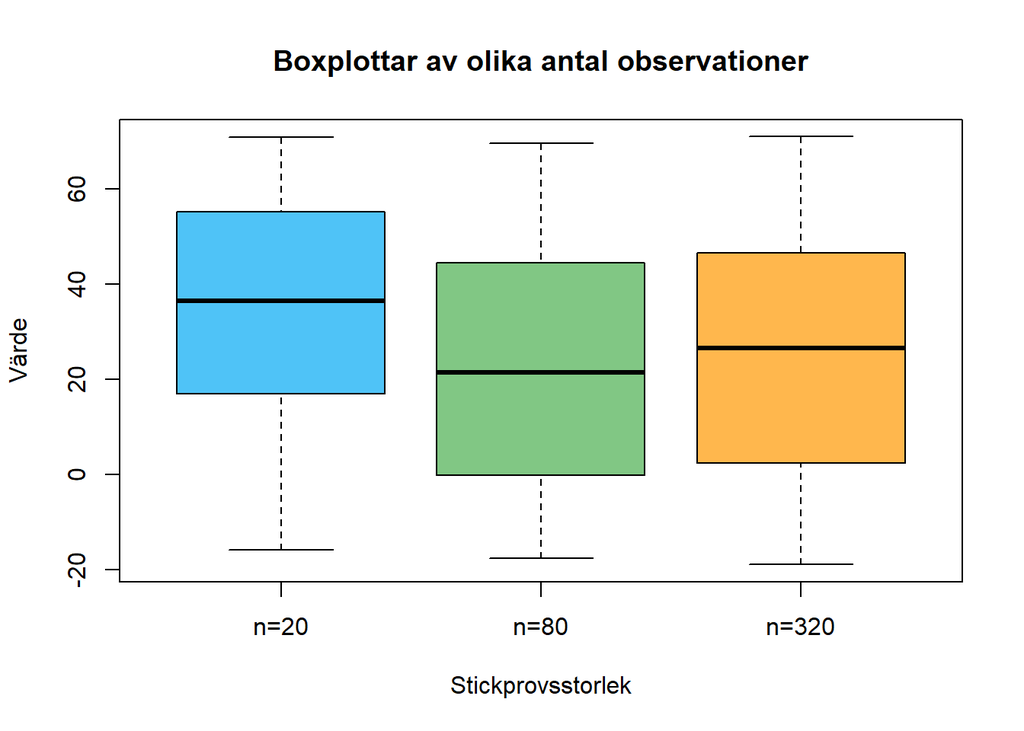

Boxplot av $U(-19.03, 71.03)$ med n=20, n=80, respektiv n=320 observationer.

```r
plot_box(u1, u2, u3)
```

### 2.2.

Jag tycker att Q-Q plotten visar tydligast att en normalfördelning eller en t-fördelning faktiskt är den fördelningen den är. Den behöver dock ganska stort n för att avgöra. I exemplen ovan, det är svårt att särskilja normalfördelning (se Figur 1) och t-fördelningen (se Figur 2) då n=80.

När n=320 är situation tydligare. I princip ligger alla punkter på linjen för normalfördelningen, medans t-fördelningens punkter börjar vrida bort från linjen mot slutet.

När det kommer till likformigfördelningen, tycker jag att ett histogram visar tydligast att den är likformig. Även vid n=20 ser likformigfördelnings histogram ganska “platt” ut (se Figur 3), medans de andra två fördelningarna har en spetsigare form (se Figurer 1 och 2). Alltså ser man förmodligen att den inte är normal vid n=20, men definitivt vid n=80.

Q-Q plotten kan också användas för att avgöra om en likformig fördelning är normal eller inte. Det behöver dock lite större n; vid n=80 (se Figur 3) blir det ganska klart att den är S-formig och således inte är normal.

# Uppgift 3

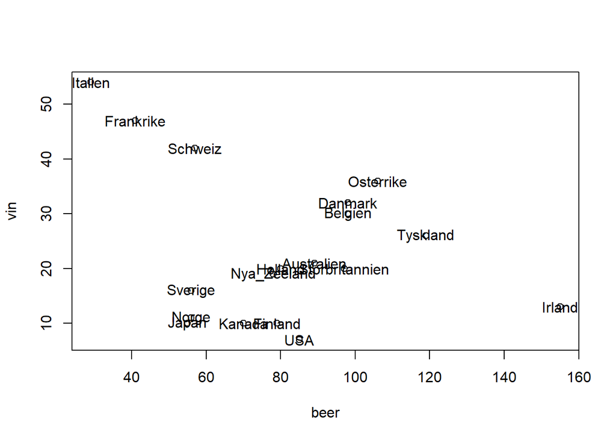

```r
data <- read.csv("olvinsprit.csv", header = TRUE)

land <- data$Land
beer <- data$beer
vin <- data$vin
sprit <- data$sprit

plot(beer, vin)
text(beer, vin, land)
```

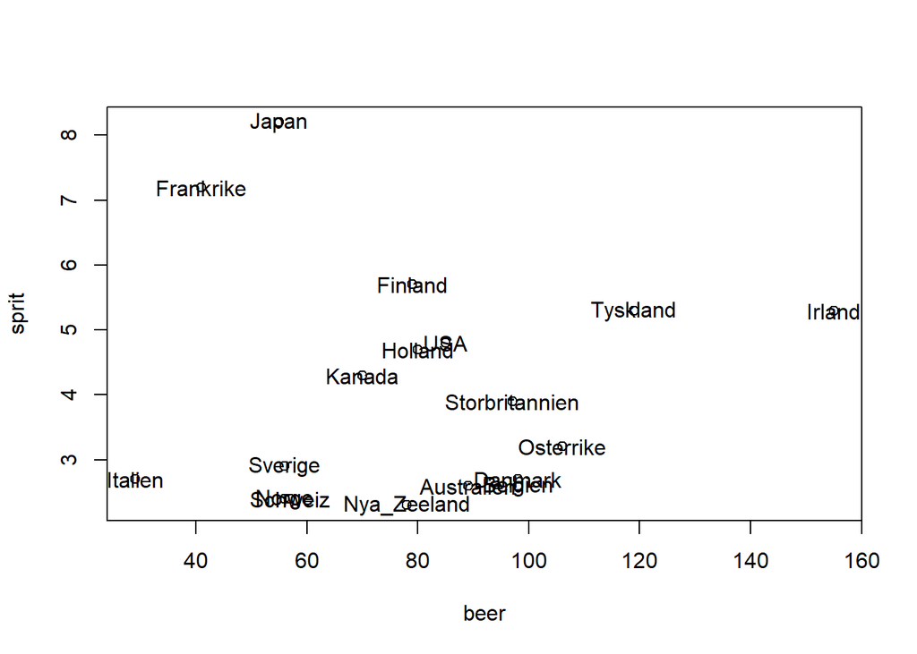

```r
plot(beer, sprit)
text(beer, sprit, land)
```

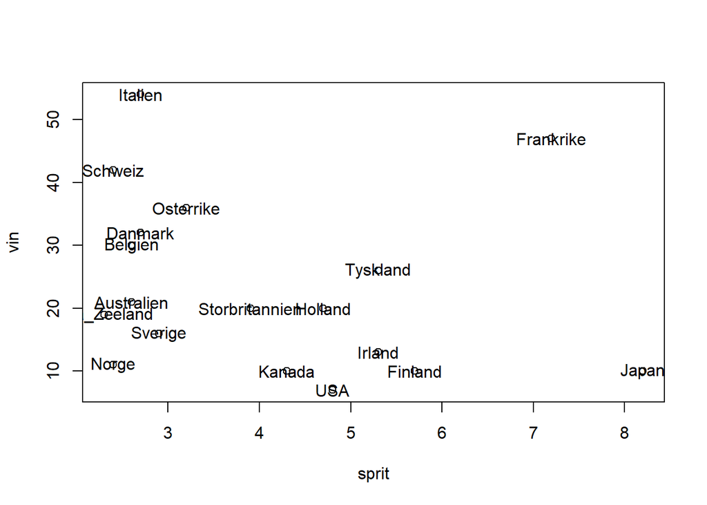

```r
plot(sprit, vin)
text(sprit, vin, land)
```

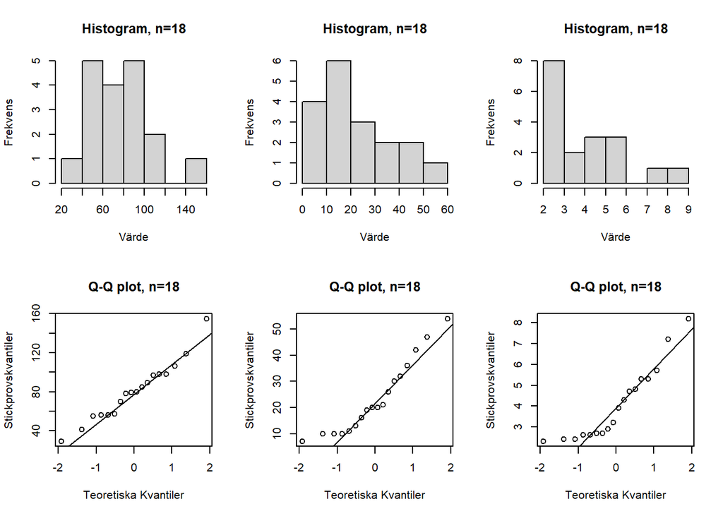

```r
plot_hist_qq(beer, vin, sprit)
```

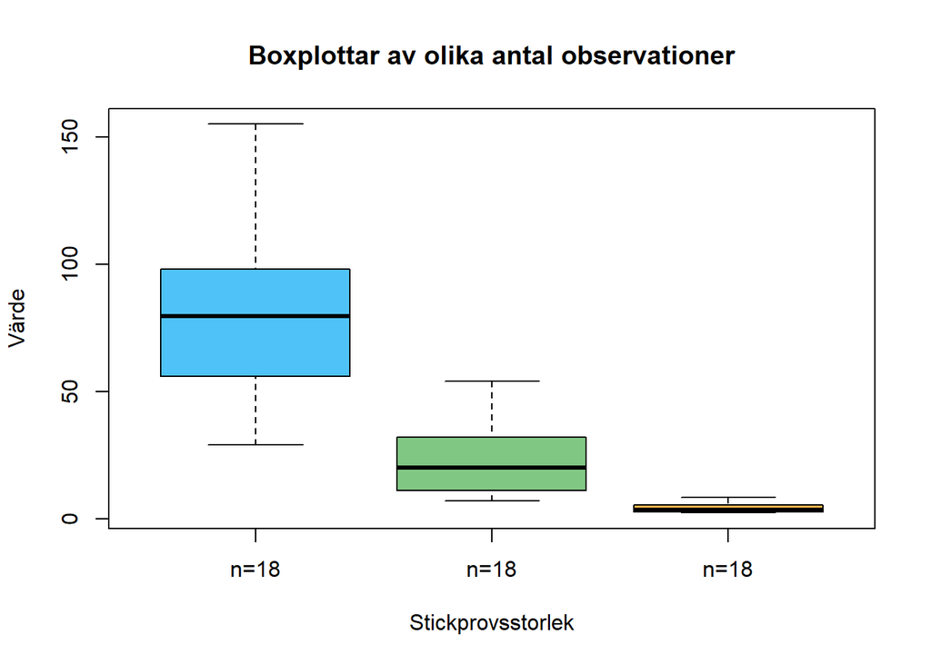

```r
plot_box(beer, vin, sprit)
```

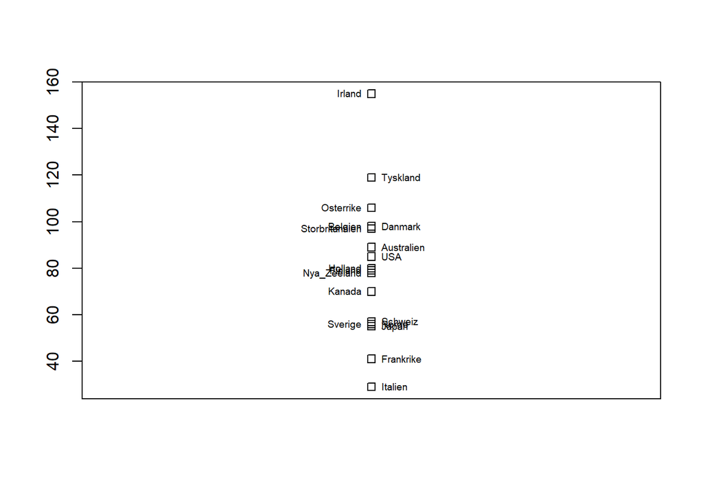

```r
stripchart(beer, vertical=TRUE)
text(1, beer, labels=land,
     pos = rep(c(2, 4), length.out = length(beer)),   # 2 = left, 4 = right
     cex = 0.6)
```